# Introduction to Image Filters

A 10-Minute Micro Lesson

Edwin Lock

## What is an image, really?

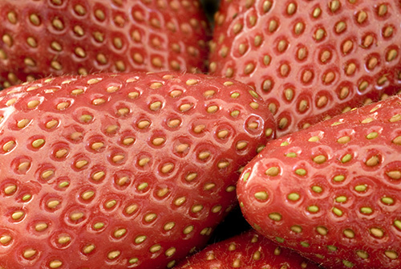

Strawberries

- An image is a **grid of pixels**
- Each pixel stores **three values**: Red, Green, Blue
- Each value ranges from **0–255**
- *(For simplicity, we’ll use grayscale today)*

## What is a filter?

- Smoothing / blurring
- Sharpening
- Noise removal
- Edge detection

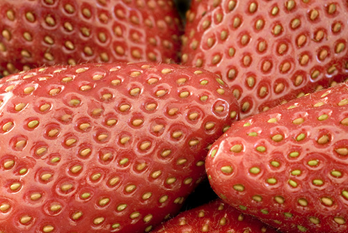

Original

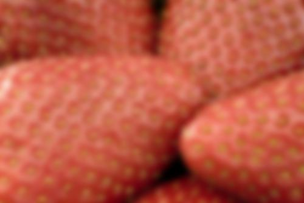

Gaussian blur

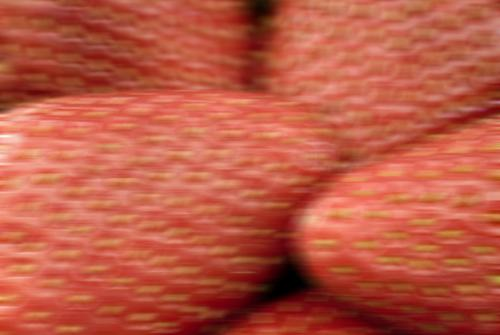

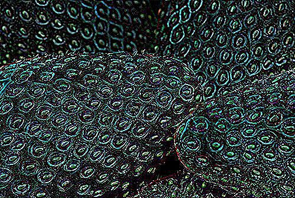

Edge detection

> A filter **transforms an image** by calculating new pixel values based on **neighbouring pixels**.

## Sharp vs. smooth

### Sharp edge

Large difference between neighbouring pixels

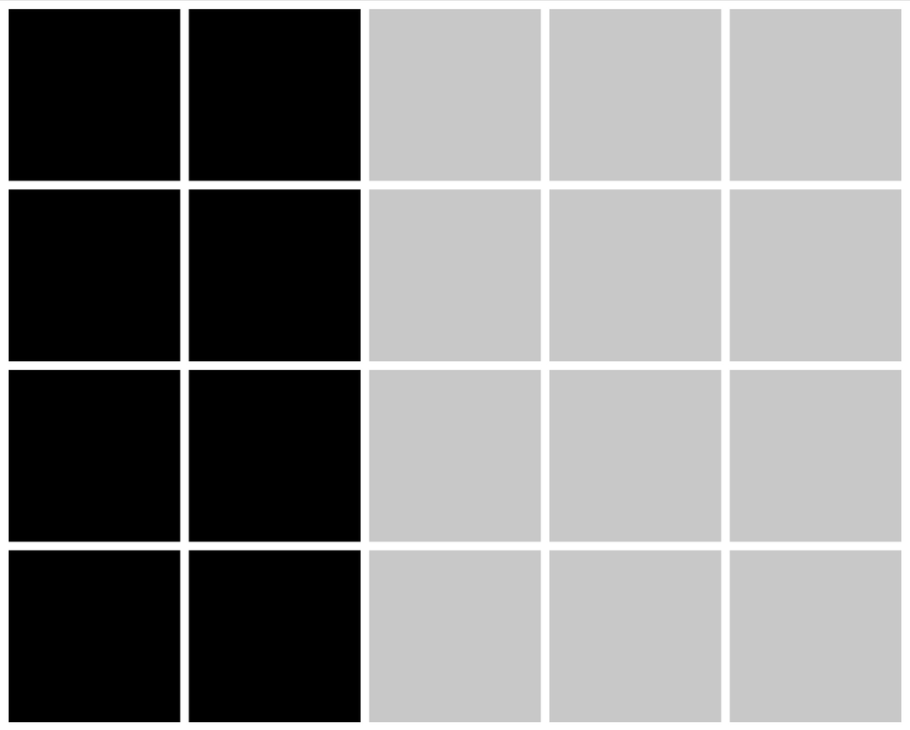

### Smooth gradient

Small difference between neighbouring pixels

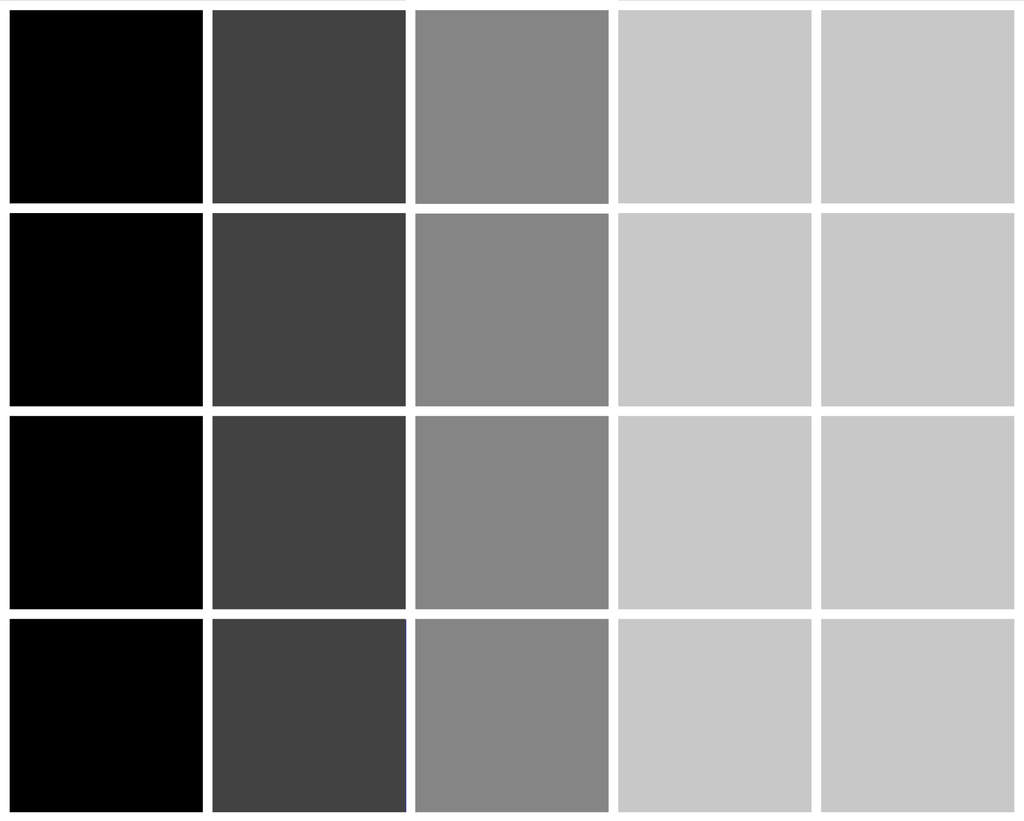

## The big idea: averaging

To smooth a pixel, **replace it with the average of itself and its neighbours**.

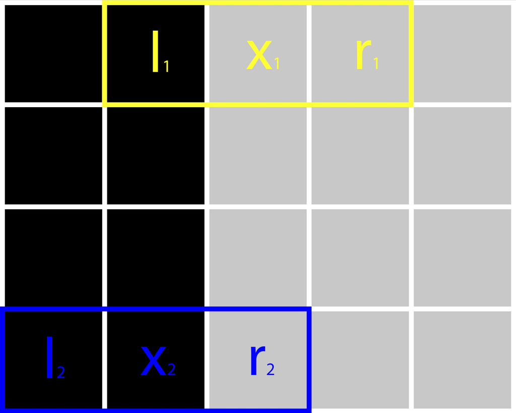

$$x' = \frac{\text{left} + x + \text{right}}{3}$$

## Example: smoothing a sharp edge

### Before

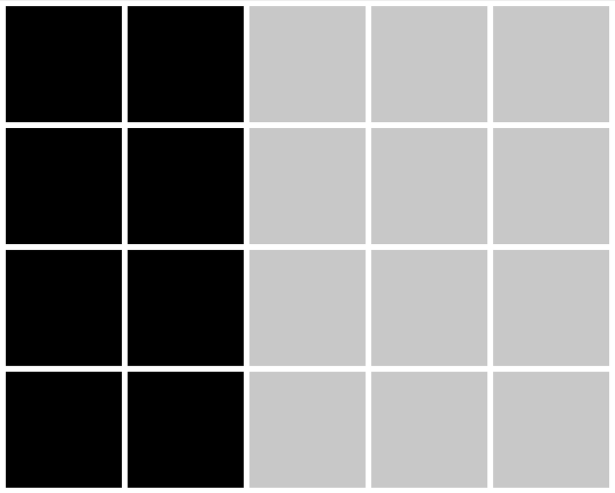

Black (0) | Grey (200)

### The calculation

At the boundary:

$x'_1 = \frac{0 + 200 + 200}{3} = 133$

$x'_2 = \frac{0 + 0 + 200}{3} = 67$

### After

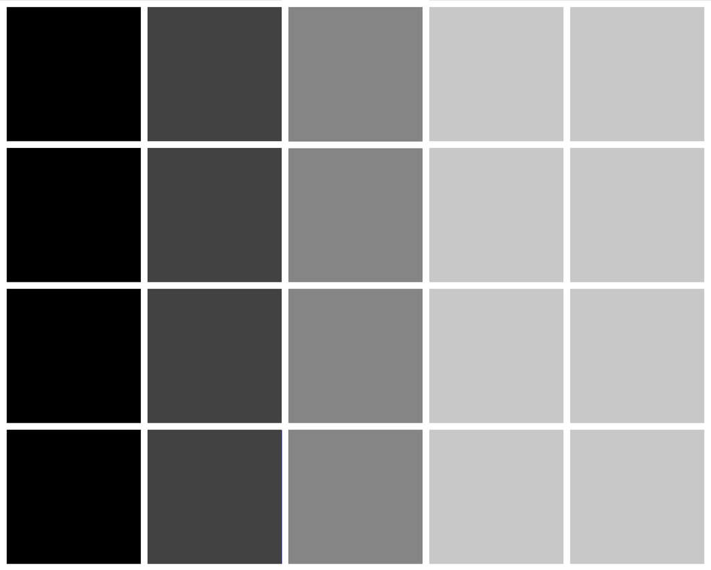

Smooth gradient!

## Going 2D: the filter region

For a truly smooth result, include **all 8 neighbours**:

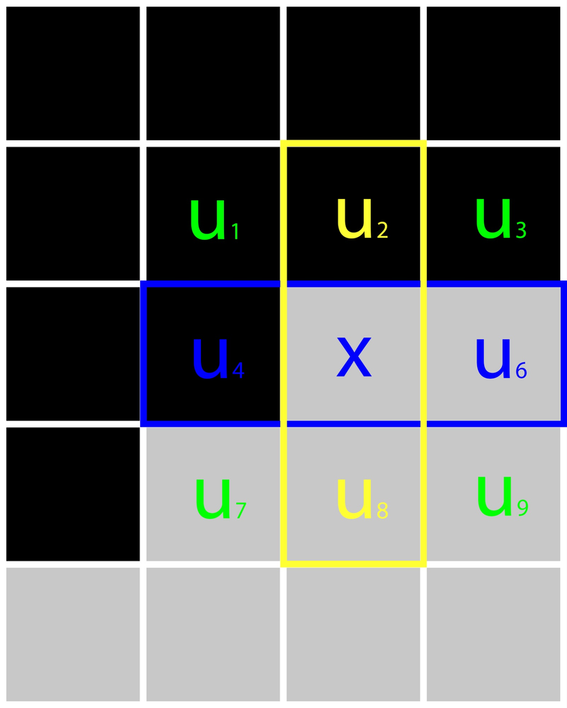

$$x' = \frac{1}{9}\sum_{i=1}^{9} u_i$$

This averages all 9 pixels in the 3×3 region.

This is called a **box filter**.

## Quick check!

**Mentimeter time**

What do you think happens if we use a **larger** filter region (e.g., 5×5 instead of 3×3)?

menti.com/alyfprbbcify

## Not all filters smooth equally

### Box filter

### Gaussian filter

### Laplace filter

Every neighbour counts **equally**

Closer neighbours count **more**

There are many different filter designs. Gaussian filters are known to produce **smoother, more natural** blurring.

## Summary

1. Images are **grids of numbers** (pixel values 0–255)
2. Filters calculate **new values from neighbours**
3. **Averaging neighbours** creates smoothing/blur
4. Larger filter regions = more blur
5. **Gaussian filters** weight closer neighbours more heavily

*Beyond smoothing: the same principles power sharpening filters and edge detection!*

## Bonus: Separable filters

A 2D box filter can be **decomposed** into two 1D filters:

$$\begin{bmatrix} 1 & 1 & 1 \\ 1 & 1 & 1 \\ 1 & 1 & 1 \end{bmatrix} = \begin{bmatrix} 1 \\ 1 \\ 1 \end{bmatrix} * \begin{bmatrix} 1 & 1 & 1 \end{bmatrix}$$

**Why does this matter?**

- 2D filter: $m \times n \times 9$ operations
- Two 1D filters: $m \times n \times 3 + m \times n \times 3 = m \times n \times 6$ operations
- **33% faster!** (and savings grow with filter size)

## Bonus: Combining filters

Convolution is **associative**: the order doesn’t matter!

$$I * (H_1 * H_2) = (I * H_1) * H_2$$

**Practical benefit:** Combine filters *before* applying to images

### Naive approach

1. Apply $H_1$ to image
2. Apply $H_2$ to result
3. Repeat for each image

### Smart approach

1. Compute $H_{combined} = H_1 * H_2$
2. Apply $H_{combined}$ to each image